# chapter6

# Exercise 6: Analysis of longitudinal data

## 1. Apply Chapter 8 exercises to RATS data

First lets load the RATS data:

```r
library(tidyverse)
RATS <- read.csv(file = here::here("data",
                                   "RATS.csv"),
                 header = TRUE,
                 row.names = 1) %>%

  #' convert categorical variables to factors
  dplyr::mutate(ID = factor(ID),
                Group = factor(Group)) %>%
  dplyr::glimpse()
```

```
## Rows: 176
## Columns: 5
## $ ID     <fct> 1, 1, 1, 1, 1, 1, 1, 1, 1, 1, 1, 2, 2, 2, 2, 2, 2, 2, 2, 2, 2, ~
## $ Group  <fct> 1, 1, 1, 1, 1, 1, 1, 1, 1, 1, 1, 1, 1, 1, 1, 1, 1, 1, 1, 1, 1, ~
## $ WD     <chr> "WD1", "WD8", "WD15", "WD22", "WD29", "WD36", "WD43", "WD44", "~
## $ Weight <int> 240, 250, 255, 260, 262, 258, 266, 266, 265, 272, 278, 225, 230~
## $ Time   <int> 1, 8, 15, 22, 29, 36, 43, 44, 50, 57, 64, 1, 8, 15, 22, 29, 36,~
```

And plot to see the general distribution of the data across our categorical variable (Group). These are the groupings used within the study across the 9-week period.

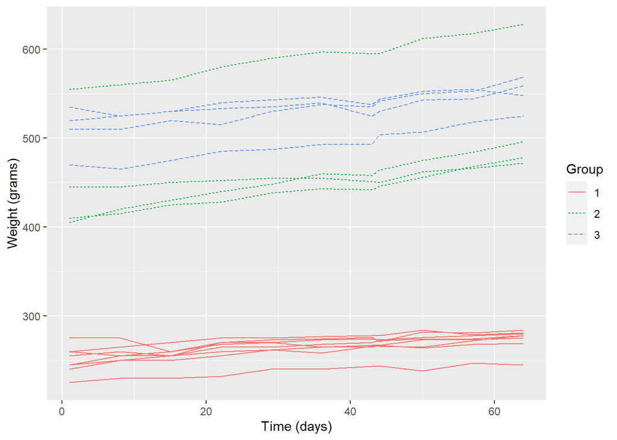

```r
ggplot2::ggplot(RATS,
       aes(x = Time,
           y = Weight,
           color = Group,
           group = ID)) +
  ggplot2::geom_line(aes(linetype = Group)) +
  ggplot2::scale_x_continuous(name = "Time (days)") +
  ggplot2::scale_y_continuous(name = "Weight (grams)")
```

Group 1 stands out. It seems that the weight of the rats in group1 was lower to begin with and weight gain was only marginal over the 9-week period. For groups 2 & 3, the starting weight were higher and they also gained significantly more weight over the same period.

Next, lets standardise the weights:

```r
RATS_st <- RATS %>%
  dplyr::group_by(Time) %>%
  dplyr::mutate(Weight_s = (Weight - mean(Weight))/sd(Weight)) %>%
  dplyr::ungroup() %>%
  dplyr::glimpse()
```

```
## Rows: 176
## Columns: 6
## $ ID       <fct> 1, 1, 1, 1, 1, 1, 1, 1, 1, 1, 1, 2, 2, 2, 2, 2, 2, 2, 2, 2, 2~
## $ Group    <fct> 1, 1, 1, 1, 1, 1, 1, 1, 1, 1, 1, 1, 1, 1, 1, 1, 1, 1, 1, 1, 1~
## $ WD       <chr> "WD1", "WD8", "WD15", "WD22", "WD29", "WD36", "WD43", "WD44",~
## $ Weight   <int> 240, 250, 255, 260, 262, 258, 266, 266, 265, 272, 278, 225, 2~
## $ Time     <int> 1, 8, 15, 22, 29, 36, 43, 44, 50, 57, 64, 1, 8, 15, 22, 29, 3~
## $ Weight_s <dbl> -1.0011429, -0.9617026, -0.9221242, -0.9383444, -0.9457447, -~
```

Re-plot using the standardised data:

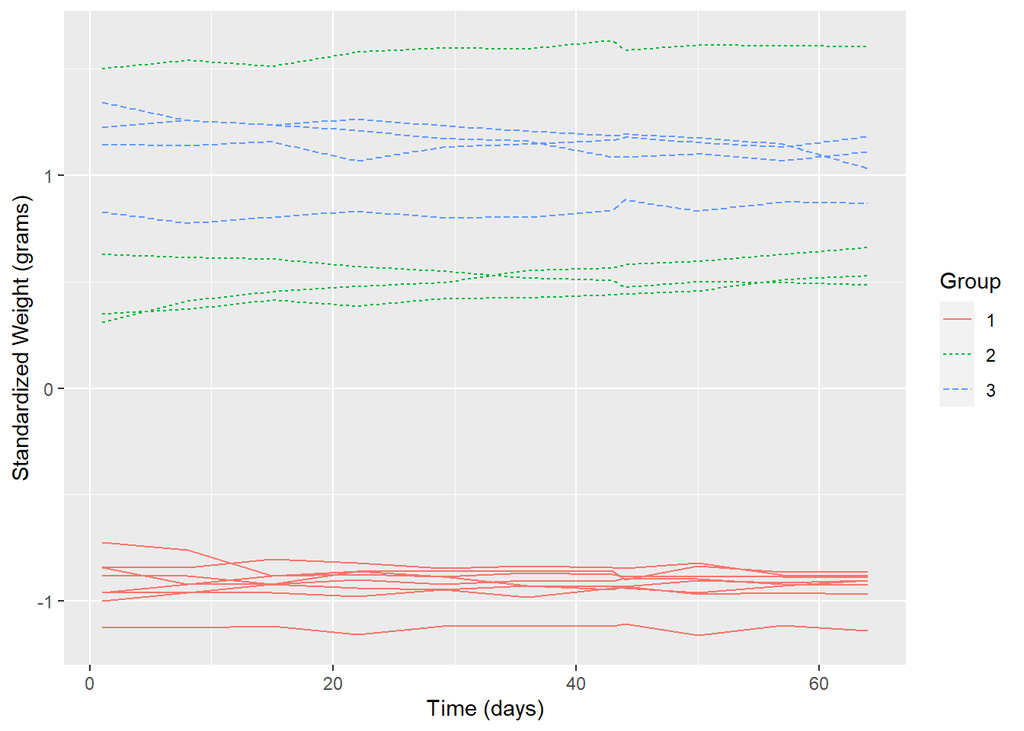

```r
ggplot2::ggplot(RATS_st, aes(x = Time,
                            y = Weight_s,
                            color = Group,
                            group = ID)) +
  ggplot2::geom_line(aes(linetype = Group)) +
  ggplot2::scale_x_continuous(name = "Time (days)") +
  ggplot2::scale_y_continuous(name = "Standardized Weight (grams)")
```

The standardised data seems to show much lower change in weight over time for all groups

```r
RATS_mod <- RATS_st %>%
  dplyr::group_by(Group, Time) %>%
  dplyr::add_tally() %>%
  dplyr::mutate(WD = factor(WD, levels = unique(WD))) %>%
  dplyr::group_by(Group, WD) %>%
  dplyr::summarise(Mean = mean(Weight), se = sd(Weight)/sqrt(n)) %>%
  dplyr::ungroup()
```

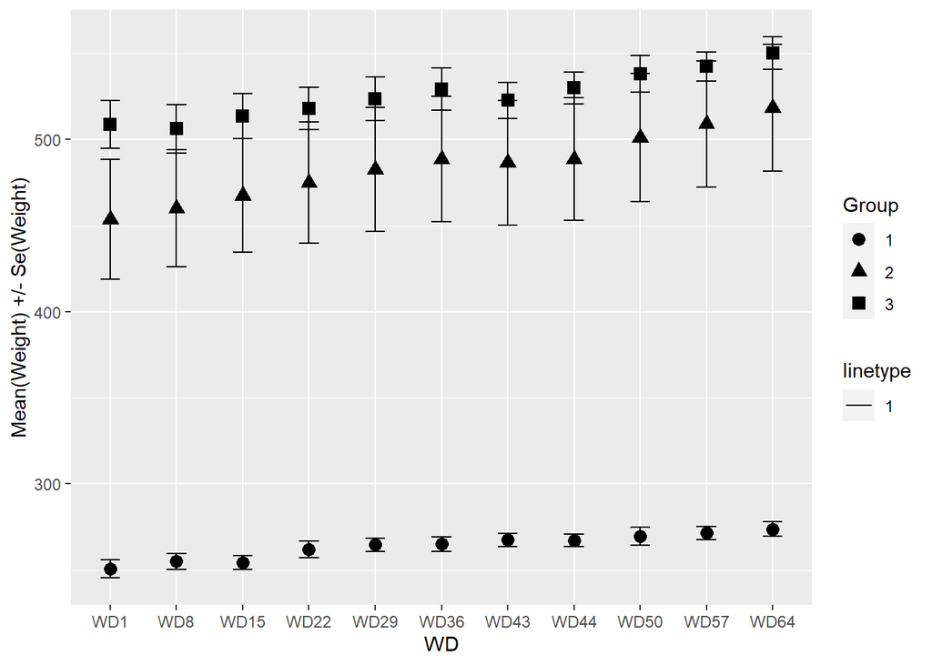

```r
ggplot2::ggplot(RATS_mod,
       aes(x = WD,
           y = Mean,
           shape = Group)) +
  ggplot2::geom_line() +
  ggplot2::scale_linetype_manual(values = c(1,2)) +
  ggplot2::geom_point(size = 3) +
  ggplot2::geom_errorbar(aes(ymin = Mean - se,
                    ymax = Mean + se,
                    linetype="1"),
                width=0.3) +
  ggplot2::theme(legend.position = "right") +
  ggplot2::scale_y_continuous(name = "Mean(Weight) +/- Se(Weight)")
```

Here we can see the mean weight per Week and the standard errors. Group 1 looks fairly even while Groups 2 & 3 have fairly wide whiskers for SE, indicating large within group variation.

Lets see if there are any outliers in the data

```r
RATS_mod.2 <- RATS_st %>%
  dplyr::filter(Time > 0) %>%
  dplyr::group_by(Group, ID) %>%
  dplyr::summarise(Mean=mean(Weight) ) %>%
  dplyr::ungroup()
```

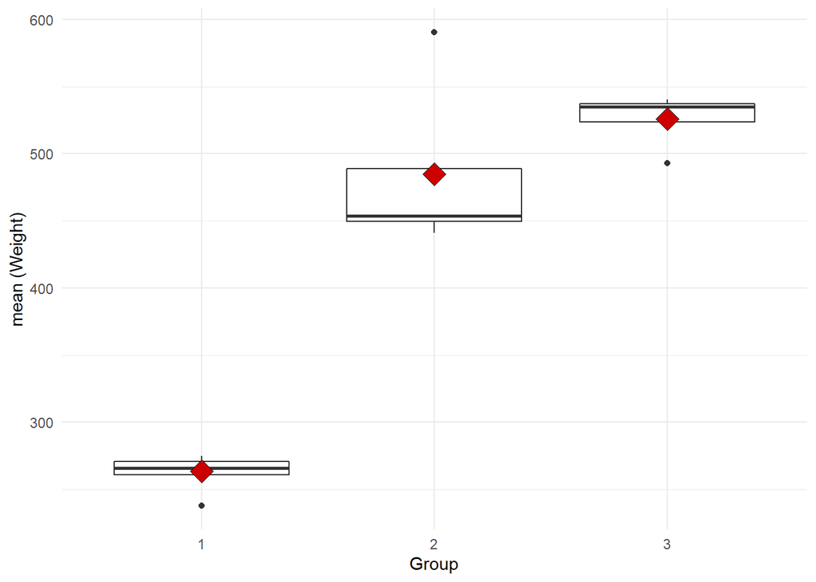

```r
ggplot2::ggplot(RATS_mod.2,
       aes(x = Group,
           y = Mean)) +
  ggplot2::geom_boxplot() +
  ggplot2::stat_summary(fun = "mean",
                        geom = "point",
                        shape = 23,
                        size = 5,
                        fill = "red3") +
  ggplot2::theme_minimal() +
  ggplot2::scale_y_continuous(name = "mean (Weight)")
```

Looks like group 2 has some outliers on the top end. Lets summarise the data and find out where to add the cutoff to remove the outliers

```r
summary(RATS_mod.2) # 550 would do it
```

```
##  Group       ID          Mean
##  1:8   1      : 1   Min.   :237.6
##  2:4   2      : 1   1st Qu.:266.3
##  3:4   3      : 1   Median :357.8
##        4      : 1   Mean   :384.5
##        5      : 1   3rd Qu.:503.1
##        6      : 1   Max.   :590.5
##        (Other):10
```

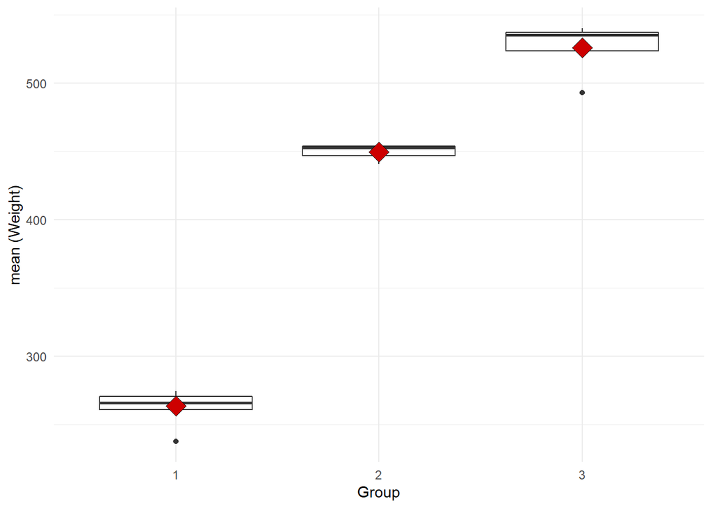

```r
RATS_mod.3 <- RATS_mod.2 %>%
  dplyr::filter(Mean < 550)

ggplot2::ggplot(RATS_mod.3,
       aes(x = Group,
           y = Mean)) +
  ggplot2::geom_boxplot() +
  ggplot2::stat_summary(fun = "mean",
                        geom = "point",
                        shape = 23,
                        size = 5,
                        fill = "red3") +
  ggplot2::theme_minimal() +
  ggplot2::scale_y_continuous(name = "mean (Weight)")
```

Now, lets fit a linear model to see whether there any statistically significant differences in the Groups.

```r
lm1 <- stats::lm(Mean ~ Group,
                 data = RATS_mod.3)
stats::anova(lm1)
```

```
## Analysis of Variance Table
##
## Response: Mean
##           Df Sum Sq Mean Sq F value    Pr(>F)
## Group      2 206390  103195   483.6 3.387e-12 ***
## Residuals 12   2561     213
## ---
## Signif. codes:  0 '***' 0.001 '**' 0.01 '*' 0.05 '.' 0.1 ' ' 1
```

Looks like there are.

## 2. Apply Chapter 9 exercises to BPRS data

Lets now load the BPRS data into the environment

```r
BPRS <- read.csv(file = here::here("data",
                                   "/BPRS.csv"),
                                   header = TRUE,
                                   row.names = 1) %>%

  #' convert categorical variables to factors
  dplyr::mutate(treatment = factor(treatment),
                subject = factor(subject)) %>%
  dplyr::glimpse()
```

```
## Rows: 360
## Columns: 5
## $ treatment <fct> 1, 1, 1, 1, 1, 1, 1, 1, 1, 1, 1, 1, 1, 1, 1, 1, 1, 1, 1, 1, ~
## $ subject   <fct> 1, 1, 1, 1, 1, 1, 1, 1, 1, 2, 2, 2, 2, 2, 2, 2, 2, 2, 3, 3, ~
## $ Vars      <chr> "week0", "week1", "week2", "week3", "week4", "week5", "week6~
## $ BPRS      <int> 42, 36, 36, 43, 41, 40, 38, 47, 51, 58, 68, 61, 55, 43, 34, ~
## $ Week      <int> 0, 1, 2, 3, 4, 5, 6, 7, 8, 0, 1, 2, 3, 4, 5, 6, 7, 8, 0, 1, ~
```

And visualise the general distribution of samples

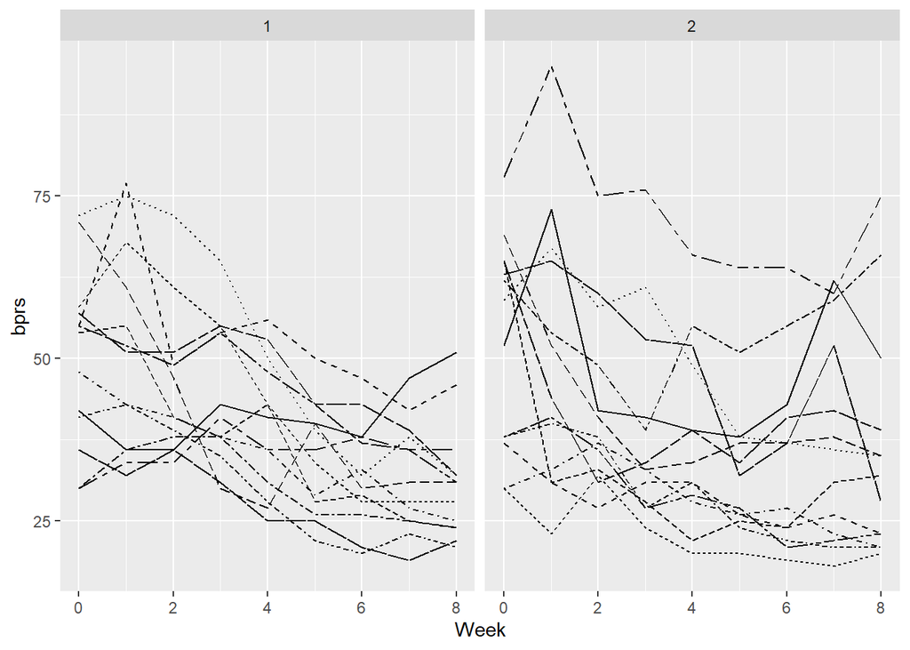

```r
ggplot2::ggplot(BPRS,
       aes(x = Week,
           y = BPRS)) +
  ggplot2::geom_line(aes(linetype = subject)) +
  ggplot2::scale_x_continuous(name = "Week") +
  ggplot2::scale_y_continuous(name = "bprs") +
  ggplot2::facet_grid(. ~ treatment) +
  ggplot2::theme(legend.position = "none")
```

From the plots it seems that the distributions are fairly similar and there might not be any differences between treatments 1 & 2.

Lets fit a model and find out:

```r
BPRS.m1 <- stats::lm(BPRS ~ Week + treatment,
                    data = BPRS)
base::summary(BPRS.m1)
```

```
##
## Call:
## stats::lm(formula = BPRS ~ Week + treatment, data = BPRS)
##
## Residuals:
##     Min      1Q  Median      3Q     Max
## -22.454  -8.965  -3.196   7.002  50.244
##
## Coefficients:
##             Estimate Std. Error t value Pr(>|t|)
## (Intercept)  46.4539     1.3670  33.982   <2e-16 ***
## Week         -2.2704     0.2524  -8.995   <2e-16 ***
## treatment2    0.5722     1.3034   0.439    0.661
## ---
## Signif. codes:  0 '***' 0.001 '**' 0.01 '*' 0.05 '.' 0.1 ' ' 1
##
## Residual standard error: 12.37 on 357 degrees of freedom
## Multiple R-squared:  0.1851, Adjusted R-squared:  0.1806
## F-statistic: 40.55 on 2 and 357 DF,  p-value: < 2.2e-16
```

Even though treatment does seem to have some effect (Estimate = 0.57), the large p.value indicates that there is no treatment related effects on BPRS.

Random intercept model:

```r
BPRS.m2 <- lme4::lmer(BPRS ~ Week + treatment + (1 | subject),
                     data = BPRS,
                     REML = F)
base::summary(BPRS.m2)
```

```
## Linear mixed model fit by maximum likelihood  ['lmerMod']
## Formula: BPRS ~ Week + treatment + (1 | subject)
##    Data: BPRS
##
##      AIC      BIC   logLik deviance df.resid
##   2748.7   2768.1  -1369.4   2738.7      355
##
## Scaled residuals:
##     Min      1Q  Median      3Q     Max
## -3.0481 -0.6749 -0.1361  0.4813  3.4855
##
## Random effects:
##  Groups   Name        Variance Std.Dev.
##  subject  (Intercept)  47.41    6.885
##  Residual             104.21   10.208
## Number of obs: 360, groups:  subject, 20
##
## Fixed effects:
##             Estimate Std. Error t value
## (Intercept)  46.4539     1.9090  24.334
## Week         -2.2704     0.2084 -10.896
## treatment2    0.5722     1.0761   0.532
##
## Correlation of Fixed Effects:
##            (Intr) Week
## Week       -0.437
## treatment2 -0.282  0.000
```

Random intercept and random slope model:

```r
BPRS.m3 <- lme4::lmer(BPRS ~ Week + treatment + (Week | subject),
                     data = BPRS,
                     REML = FALSE)
base::summary(BPRS.m3)
```

```
## Linear mixed model fit by maximum likelihood  ['lmerMod']
## Formula: BPRS ~ Week + treatment + (Week | subject)
##    Data: BPRS
##
##      AIC      BIC   logLik deviance df.resid
##   2745.4   2772.6  -1365.7   2731.4      353
##
## Scaled residuals:
##     Min      1Q  Median      3Q     Max
## -2.8919 -0.6194 -0.0691  0.5531  3.7976
##
## Random effects:
##  Groups   Name        Variance Std.Dev. Corr
##  subject  (Intercept) 64.8222  8.0512
##           Week         0.9609  0.9802   -0.51
##  Residual             97.4305  9.8707
## Number of obs: 360, groups:  subject, 20
##
## Fixed effects:
##             Estimate Std. Error t value
## (Intercept)  46.4539     2.1052  22.066
## Week         -2.2704     0.2977  -7.626
## treatment2    0.5722     1.0405   0.550
##
## Correlation of Fixed Effects:
##            (Intr) Week
## Week       -0.582
## treatment2 -0.247  0.000
```

Anova for model comparisons:

```r
stats::anova(BPRS.m3, BPRS.m2)
```

```
## Data: BPRS
## Models:
## BPRS.m2: BPRS ~ Week + treatment + (1 | subject)
## BPRS.m3: BPRS ~ Week + treatment + (Week | subject)
##         npar    AIC    BIC  logLik deviance  Chisq Df Pr(>Chisq)
## BPRS.m2    5 2748.7 2768.1 -1369.4   2738.7
## BPRS.m3    7 2745.4 2772.6 -1365.7   2731.4 7.2721  2    0.02636 *
## ---
## Signif. codes:  0 '***' 0.001 '**' 0.01 '*' 0.05 '.' 0.1 ' ' 1
```

Now lets see how fitted values would look

```r
BPRS.m4 <- lme4::lmer(BPRS ~ Week + treatment + Week*treatment + (Week | subject),
                data = BPRS,
                REML = F)
summary(BPRS.m4)
```

```
## Linear mixed model fit by maximum likelihood  ['lmerMod']
## Formula: BPRS ~ Week + treatment + Week * treatment + (Week | subject)
##    Data: BPRS
##
##      AIC      BIC   logLik deviance df.resid
##   2744.3   2775.4  -1364.1   2728.3      352
##
## Scaled residuals:
##     Min      1Q  Median      3Q     Max
## -3.0513 -0.6271 -0.0768  0.5288  3.9260
##
## Random effects:
##  Groups   Name        Variance Std.Dev. Corr
##  subject  (Intercept) 65.0048  8.0626
##           Week         0.9687  0.9842   -0.51
##  Residual             96.4702  9.8219
## Number of obs: 360, groups:  subject, 20
##
## Fixed effects:
##                 Estimate Std. Error t value
## (Intercept)      47.8856     2.2522  21.262
## Week             -2.6283     0.3589  -7.323
## treatment2       -2.2911     1.9090  -1.200
## Week:treatment2   0.7158     0.4010   1.785
##
## Correlation of Fixed Effects:
##             (Intr) Week   trtmn2
## Week        -0.650
## treatment2  -0.424  0.469
## Wek:trtmnt2  0.356 -0.559 -0.840
```

```r
# ANOVA
stats::anova(BPRS.m4, BPRS.m3)
```

```
## Data: BPRS
## Models:
## BPRS.m3: BPRS ~ Week + treatment + (Week | subject)
## BPRS.m4: BPRS ~ Week + treatment + Week * treatment + (Week | subject)
##         npar    AIC    BIC  logLik deviance  Chisq Df Pr(>Chisq)
## BPRS.m3    7 2745.4 2772.6 -1365.7   2731.4
## BPRS.m4    8 2744.3 2775.4 -1364.1   2728.3 3.1712  1    0.07495 .
## ---
## Signif. codes:  0 '***' 0.001 '**' 0.01 '*' 0.05 '.' 0.1 ' ' 1
```

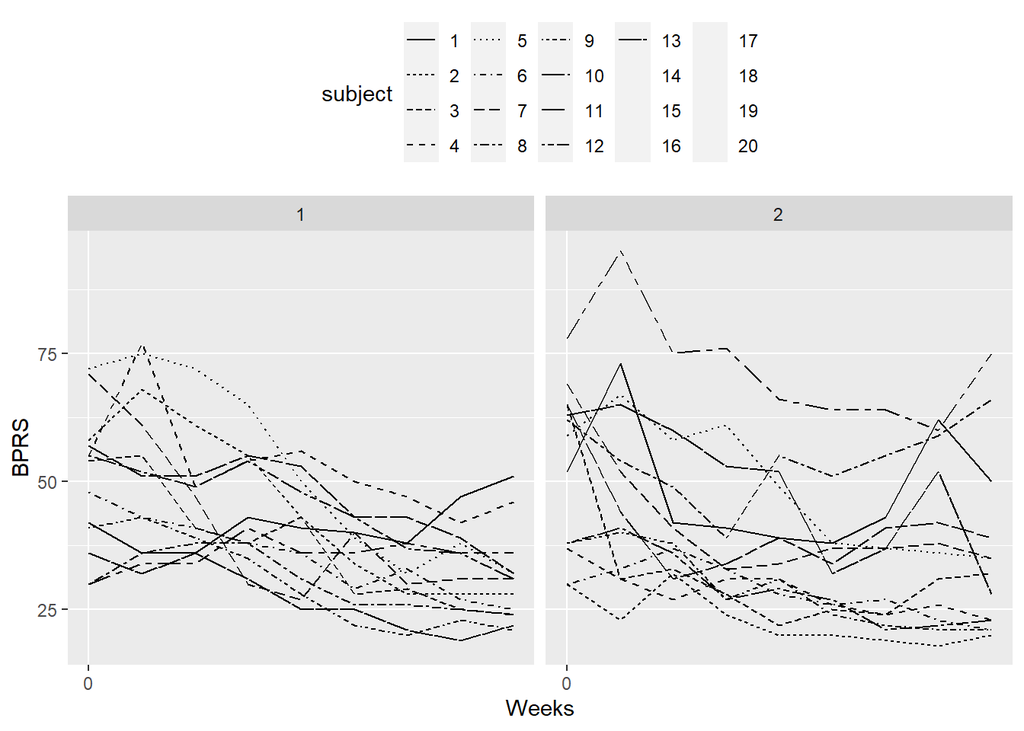

```r
# Earlier plot
ggplot2::ggplot(BPRS, aes(x = Week,
                 y = BPRS,
                 group = subject)) +
  ggplot2::geom_line(aes(linetype = subject)) +
  ggplot2::scale_x_continuous(name = "Weeks", breaks = seq(0, 60, 20)) +
  ggplot2::scale_y_continuous(name = "BPRS") +
  ggplot2::facet_grid(. ~ treatment) +
  ggplot2::theme(legend.position = "top")
```

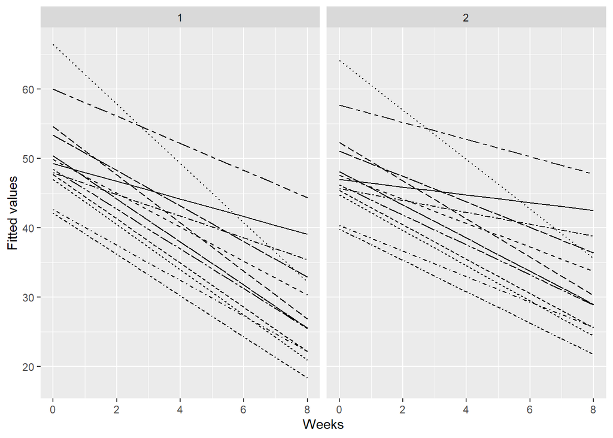

```r
# plot with fitted values
Fitted <- stats::fitted(BPRS.m4)

BPRS <- BPRS %>%
  mutate(Fitted)

ggplot2::ggplot(BPRS, aes(x = Week,
                 y = Fitted,
                 group = subject)) +
  ggplot2::geom_line(aes(linetype = subject)) +
  ggplot2::scale_x_continuous(name = "Weeks") +
  ggplot2::scale_y_continuous(name = "Fitted values") +
  ggplot2::facet_grid(. ~ treatment) +
  ggplot2::theme(legend.position = "none")
```

Initially it did look like the interaction terms (Week:treatment) might have a higher overall effect but it does not seem like the model was improved too much.